# Cyclistic Bike Share Data Analysis

Aninon Jeffrey Egbejule

6/20/2023

# Google Data Analytics Certificate Capstone Project

## Introduction:

Hello, my name is Aninon J. Egbejule, and welcome to my capstone project for the Google Data Analytics Certification. In this project I am working for Cyclistic, a fictional bike share company in Chicago. Until now, Cyclistic’s marketing strategy relied on building general awareness and appealing to broad consumer segments. One approach responsible for Cyclistic’s success, was the flexibility of its pricing plans: single-ride passes, full-day passes, and annual memberships. Customers who purchase single-ride or full-day passes are referred to as casual riders. Customers who purchase annual memberships are Cyclistic members.

Cyclistic’s finance analysts have concluded that annual members are much more profitable than casual riders. Although the pricing flexibility helps Cyclistic attract more customers, the director of marketing believes that maximizing the number of annual members will be key to future growth. Rather than creating a marketing campaign that targets all-new customers, she believes there is a very good chance to convert casual riders into members. She notes that casual riders are already aware of the Cyclistic program and have chosen Cyclistic for their mobility needs

## Goal:

Design marketing strategies aimed at converting casual riders into annual members. In order to do that, however, the marketing analyst team needs to better understand how annual members and casual riders differ, why casual riders would buy a membership, and how digital media could affect their marketing tactics.

Three questions will guide the future marketing program:

1. How do annual members and casual riders use Cyclistic bikes differently?
2. Why would casual riders buy Cyclistic annual memberships?
3. How can Cyclistic use digital media to influence casual riders to become members?

The director of marketing has assigned me the first question to answer: How do annual members and casual riders use Cyclistic bikes differently?

## The business task:

Analyze cyclistic’s 2022 historical annual ride share dataset and identify key trends and differences between its annual members and casual riders.

## Data used:

The data used for this analysis can be found [here](https://divvy-tripdata.s3.amazonaws.com/index.html). For this project I used use the 12 months datasets of Cyclistic trip data for 2022. The data has been made available by Motivate International Inc. under this [license](https://ride.divvybikes.com/data-license-agreement).

Each file contains the following thirteen columns of data about all rides that took place during the months of January 2022 to December 2022

1. ride_id: Primary key, identifies each individual ride.
2. rideable_type: Type of bike rode.
3. started_at: Date and time ride begins.
4. ended_at: Date and time ride ends.
5. start_station_name: Name of station where ride begins.
6. start_station_id: Unique id of station where ride begins.
7. end_station_name: Name of station where ride ends.
8. end_station_id: Unique id of station where ride ends.
9. start_lat: Latitude of ride start.
10. start_lng: Longitude of ride start.
11. end_lat: Latitude of ride end.
12. end_lng: Longitude of ride end.
13. member_casual: Rider type, ‘member’ or ‘casual’.

## Data Preparation

### Setting up my environment

```r
# Load libraries in R workspace
library(tidyverse)
library(tidyr)
library(purrr)
library(dplyr)
library(lubridate)
library(readr)
library(janitor)
library(scales)
library(leaflet)
library(shiny)
library(htmlwidgets)
```

#### Imported all 12 datasets, one for each month of the year 2022

```r
# Import all 12 datasets, one for each month of the year
cyclistic_01_2022 <- read_csv("~/Documents/R/2022 Cyclistic Data Set/2022 Cyclistic CSV Files/202201-divvy-tripdata.csv")
cyclistic_02_2022 <- read_csv("~/Documents/R/2022 Cyclistic Data Set/2022 Cyclistic CSV Files/202202-divvy-tripdata.csv")
cyclistic_03_2022 <- read_csv("~/Documents/R/2022 Cyclistic Data Set/2022 Cyclistic CSV Files/202203-divvy-tripdata.csv")
cyclistic_04_2022 <- read_csv("~/Documents/R/2022 Cyclistic Data Set/2022 Cyclistic CSV Files/202204-divvy-tripdata.csv")
cyclistic_05_2022 <- read_csv("~/Documents/R/2022 Cyclistic Data Set/2022 Cyclistic CSV Files/202205-divvy-tripdata.csv")
cyclistic_06_2022 <- read_csv("~/Documents/R/2022 Cyclistic Data Set/2022 Cyclistic CSV Files/202206-divvy-tripdata.csv")
cyclistic_07_2022 <- read_csv("~/Documents/R/2022 Cyclistic Data Set/2022 Cyclistic CSV Files/202207-divvy-tripdata.csv")
cyclistic_08_2022 <- read_csv("~/Documents/R/2022 Cyclistic Data Set/2022 Cyclistic CSV Files/202208-divvy-tripdata.csv")
cyclistic_09_2022 <- read_csv("~/Documents/R/2022 Cyclistic Data Set/2022 Cyclistic CSV Files/202209-divvy-tripdata.csv")
cyclistic_10_2022 <- read_csv("~/Documents/R/2022 Cyclistic Data Set/2022 Cyclistic CSV Files/202210-divvy-tripdata.csv")
cyclistic_11_2022 <- read_csv("~/Documents/R/2022 Cyclistic Data Set/2022 Cyclistic CSV Files/202211-divvy-tripdata.csv")
cyclistic_12_2022 <- read_csv("~/Documents/R/2022 Cyclistic Data Set/2022 Cyclistic CSV Files/202212-divvy-tripdata.csv")
```

#### Combined all 12 datasets to form 1 annual dataset

```r
# Merged all 12 datasets to form 1 annual dataset
cyclistic_2022_merged <- do.call("rbind", list(cyclistic_01_2022, cyclistic_02_2022, cyclistic_03_2022, cyclistic_04_2022, cyclistic_05_2022, cyclistic_06_2022, cyclistic_07_2022, cyclistic_08_2022, cyclistic_09_2022, cyclistic_10_2022, cyclistic_11_2022, cyclistic_12_2022))

head(cyclistic_2022_merged)
```

```
## # A tibble: 6 × 13
##   ride_id          rideable_type started_at          ended_at
##   <chr>            <chr>         <dttm>              <dttm>
## 1 C2F7DD78E82EC875 electric_bike 2022-01-13 11:59:47 2022-01-13 12:02:44
## 2 A6CF8980A652D272 electric_bike 2022-01-10 08:41:56 2022-01-10 08:46:17
## 3 BD0F91DFF741C66D classic_bike  2022-01-25 04:53:40 2022-01-25 04:58:01
## 4 CBB80ED419105406 classic_bike  2022-01-04 00:18:04 2022-01-04 00:33:00
## 5 DDC963BFDDA51EEA classic_bike  2022-01-20 01:31:10 2022-01-20 01:37:12
## 6 A39C6F6CC0586C0B classic_bike  2022-01-11 18:48:09 2022-01-11 18:51:31
## # ℹ 9 more variables: start_station_name <chr>, start_station_id <chr>,
## #   end_station_name <chr>, end_station_id <chr>, start_lat <dbl>,
## #   start_lng <dbl>, end_lat <dbl>, end_lng <dbl>, member_casual <chr>
```

#### Inspected the new data frame for missing values

```r
# Check for missing values
missing_values <- colSums(is.na(cyclistic_2022_merged))

# Print the columns with missing values
print(missing_values[missing_values > 0])
```

```
## start_station_name   start_station_id   end_station_name     end_station_id
##             833064             833064             892742             892742
##            end_lat            end_lng
##               5858               5858
```

## Data Cleaning:

For data cleaning and analysis R and RStudio were used.

The following steps were taken during data cleaning:

- Checked all data for duplicate rows. (None found)
- Checked for and removed NULL’s or NA values
- Made sure all latitudes and longitudes contained at least 2 digits
- Made sure all rows in the member_casual column contained the word ‘member’ or ‘casual’
- Made sure all rows in the rideable_type column contained 1 of the 3 types of bikes
- Checked for and removed any rows that have an end time that is before the start time
- Created new data frame of cleaned data and added columns for:
  - start_day_of_week: Day of the week ride begins.
  - end_day_of_week: Day of the week ride ends.
  - ride_length: Duration of the ride in seconds.
  - ride_length_minutes : Duration of the ride in minutes
  - start_time: Time ride started in hms format
  - month: Month of the ride

```r
# Cleaned the dataset using a pipe operation
cyclistic_2022_cleaned <- cyclistic_2022_merged %>%
  distinct() %>%
  na.omit() %>%
  filter(floor(log10(abs(start_lat))) + 1 >= 2 &
    floor(log10(abs(start_lng))) + 1 >= 2 &
    floor(log10(abs(end_lat))) + 1 >= 2 &
    floor(log10(abs(end_lng))) + 1 >= 2) %>%
  filter(member_casual == "member" | member_casual == "casual") %>%
  filter(rideable_type == "classic_bike" | rideable_type == "electric_bike" |
    rideable_type == "docked_bike") %>%
  filter(ended_at > started_at) %>%
  mutate(
    start_day_of_the_week = weekdays(started_at),
    end_day_of_the_week = weekdays(ended_at),
    ride_length = difftime(ended_at, started_at),
    month = month(started_at, label = TRUE)
  ) %>%
  mutate(ride_length_mins = round(difftime(ended_at, started_at,
    units = "min"
  ), digits = 2)) %>%
  mutate(start_time = format(started_at, format = "%H:%M:%S")) %>%
  mutate(hour_time = format(started_at, format = "%H"))

head(cyclistic_2022_cleaned)
```

```
## # A tibble: 6 × 20
##   ride_id          rideable_type started_at          ended_at
##   <chr>            <chr>         <dttm>              <dttm>
## 1 C2F7DD78E82EC875 electric_bike 2022-01-13 11:59:47 2022-01-13 12:02:44
## 2 A6CF8980A652D272 electric_bike 2022-01-10 08:41:56 2022-01-10 08:46:17
## 3 BD0F91DFF741C66D classic_bike  2022-01-25 04:53:40 2022-01-25 04:58:01
## 4 CBB80ED419105406 classic_bike  2022-01-04 00:18:04 2022-01-04 00:33:00
## 5 DDC963BFDDA51EEA classic_bike  2022-01-20 01:31:10 2022-01-20 01:37:12
## 6 A39C6F6CC0586C0B classic_bike  2022-01-11 18:48:09 2022-01-11 18:51:31
## # ℹ 16 more variables: start_station_name <chr>, start_station_id <chr>,
## #   end_station_name <chr>, end_station_id <chr>, start_lat <dbl>,
## #   start_lng <dbl>, end_lat <dbl>, end_lng <dbl>, member_casual <chr>,
## #   start_day_of_the_week <chr>, end_day_of_the_week <chr>, ride_length <drtn>,
## #   month <ord>, ride_length_mins <drtn>, start_time <chr>, hour_time <chr>
```

#### Checked the proportion of the cleaned dataset relative to the original dataset

```r
# Proportion of rides in cleaned data set verus original dataset
nrow(cyclistic_2022_cleaned)/nrow(cyclistic_2022_merged)*100
```

```
## [1] 77.08649
```

#### Inspected the new table that has been created for accuracy and completeness

```r
#List of column names
colnames(cyclistic_2022_cleaned)
```

```
##  [1] "ride_id"               "rideable_type"         "started_at"
##  [4] "ended_at"              "start_station_name"    "start_station_id"
##  [7] "end_station_name"      "end_station_id"        "start_lat"
## [10] "start_lng"             "end_lat"               "end_lng"
## [13] "member_casual"         "start_day_of_the_week" "end_day_of_the_week"
## [16] "ride_length"           "month"                 "ride_length_mins"
## [19] "start_time"            "hour_time"
```

```r
#How many rows are in data frame?
nrow(cyclistic_2022_cleaned)
```

```
## [1] 4369044
```

```r
#Dimensions of the data frame?
dim(cyclistic_2022_cleaned)
```

```
## [1] 4369044      20
```

```r
#See the first 6 rows of data frame.  Also tail(all_trips)
head(cyclistic_2022_cleaned)
```

```
## # A tibble: 6 × 20
##   ride_id          rideable_type started_at          ended_at
##   <chr>            <chr>         <dttm>              <dttm>
## 1 C2F7DD78E82EC875 electric_bike 2022-01-13 11:59:47 2022-01-13 12:02:44
## 2 A6CF8980A652D272 electric_bike 2022-01-10 08:41:56 2022-01-10 08:46:17
## 3 BD0F91DFF741C66D classic_bike  2022-01-25 04:53:40 2022-01-25 04:58:01
## 4 CBB80ED419105406 classic_bike  2022-01-04 00:18:04 2022-01-04 00:33:00
## 5 DDC963BFDDA51EEA classic_bike  2022-01-20 01:31:10 2022-01-20 01:37:12
## 6 A39C6F6CC0586C0B classic_bike  2022-01-11 18:48:09 2022-01-11 18:51:31
## # ℹ 16 more variables: start_station_name <chr>, start_station_id <chr>,
## #   end_station_name <chr>, end_station_id <chr>, start_lat <dbl>,
## #   start_lng <dbl>, end_lat <dbl>, end_lng <dbl>, member_casual <chr>,
## #   start_day_of_the_week <chr>, end_day_of_the_week <chr>, ride_length <drtn>,
## #   month <ord>, ride_length_mins <drtn>, start_time <chr>, hour_time <chr>
```

```r
#See list of columns and data types (numeric, character, etc)
str(cyclistic_2022_cleaned)
```

```
## tibble [4,369,044 × 20] (S3: tbl_df/tbl/data.frame)
##  $ ride_id              : chr [1:4369044] "C2F7DD78E82EC875" "A6CF8980A652D272" "BD0F91DFF741C66D" "CBB80ED419105406" ...
##  $ rideable_type        : chr [1:4369044] "electric_bike" "electric_bike" "classic_bike" "classic_bike" ...
##  $ started_at           : POSIXct[1:4369044], format: "2022-01-13 11:59:47" "2022-01-10 08:41:56" ...
##  $ ended_at             : POSIXct[1:4369044], format: "2022-01-13 12:02:44" "2022-01-10 08:46:17" ...
##  $ start_station_name   : chr [1:4369044] "Glenwood Ave & Touhy Ave" "Glenwood Ave & Touhy Ave" "Sheffield Ave & Fullerton Ave" "Clark St & Bryn Mawr Ave" ...
##  $ start_station_id     : chr [1:4369044] "525" "525" "TA1306000016" "KA1504000151" ...
##  $ end_station_name     : chr [1:4369044] "Clark St & Touhy Ave" "Clark St & Touhy Ave" "Greenview Ave & Fullerton Ave" "Paulina St & Montrose Ave" ...
##  $ end_station_id       : chr [1:4369044] "RP-007" "RP-007" "TA1307000001" "TA1309000021" ...
##  $ start_lat            : num [1:4369044] 42 42 41.9 42 41.9 ...
##  $ start_lng            : num [1:4369044] -87.7 -87.7 -87.7 -87.7 -87.6 ...
##  $ end_lat              : num [1:4369044] 42 42 41.9 42 41.9 ...
##  $ end_lng              : num [1:4369044] -87.7 -87.7 -87.7 -87.7 -87.6 ...
##  $ member_casual        : chr [1:4369044] "casual" "casual" "member" "casual" ...
##  $ start_day_of_the_week: chr [1:4369044] "Thursday" "Monday" "Tuesday" "Tuesday" ...
##  $ end_day_of_the_week  : chr [1:4369044] "Thursday" "Monday" "Tuesday" "Tuesday" ...
##  $ ride_length          : 'difftime' num [1:4369044] 177 261 261 896 ...
##   ..- attr(*, "units")= chr "secs"
##  $ month                : Ord.factor w/ 12 levels "Jan"<"Feb"<"Mar"<..: 1 1 1 1 1 1 1 1 1 1 ...
##  $ ride_length_mins     : 'difftime' num [1:4369044] 2.95 4.35 4.35 14.93 ...
##   ..- attr(*, "units")= chr "mins"
##  $ start_time           : chr [1:4369044] "11:59:47" "08:41:56" "04:53:40" "00:18:04" ...
##  $ hour_time            : chr [1:4369044] "11" "08" "04" "00" ...
##  - attr(*, "na.action")= 'omit' Named int [1:1298357] 257 511 513 980 981 1080 1081 1084 1143 1200 ...
##   ..- attr(*, "names")= chr [1:1298357] "257" "511" "513" "980" ...
```

```r
#Statistical summary of data. Mainly for numerics
summary(cyclistic_2022_cleaned)
```

```
##    ride_id          rideable_type        started_at
##  Length:4369044     Length:4369044     Min.   :2022-01-01 00:00:05
##  Class :character   Class :character   1st Qu.:2022-05-29 10:29:30
##  Mode  :character   Mode  :character   Median :2022-07-20 21:21:52
##                                        Mean   :2022-07-19 14:05:44
##                                        3rd Qu.:2022-09-14 18:22:08
##                                        Max.   :2022-12-31 23:59:26
##
##     ended_at                   start_station_name start_station_id
##  Min.   :2022-01-01 00:01:48   Length:4369044     Length:4369044
##  1st Qu.:2022-05-29 10:53:26   Class :character   Class :character
##  Median :2022-07-20 21:39:53   Mode  :character   Mode  :character
##  Mean   :2022-07-19 14:22:50
##  3rd Qu.:2022-09-14 18:38:22
##  Max.   :2023-01-01 18:09:37
##
##  end_station_name   end_station_id       start_lat       start_lng
##  Length:4369044     Length:4369044     Min.   :41.65   Min.   :-87.83
##  Class :character   Class :character   1st Qu.:41.88   1st Qu.:-87.66
##  Mode  :character   Mode  :character   Median :41.90   Median :-87.64
##                                        Mean   :41.90   Mean   :-87.64
##                                        3rd Qu.:41.93   3rd Qu.:-87.63
##                                        Max.   :45.64   Max.   :-73.80
##
##     end_lat         end_lng       member_casual      start_day_of_the_week
##  Min.   :41.65   Min.   :-87.83   Length:4369044     Length:4369044
##  1st Qu.:41.88   1st Qu.:-87.66   Class :character   Class :character
##  Median :41.90   Median :-87.64   Mode  :character   Mode  :character
##  Mean   :41.90   Mean   :-87.65
##  3rd Qu.:41.93   3rd Qu.:-87.63
##  Max.   :42.06   Max.   :-87.53
##
##  end_day_of_the_week ride_length           month         ride_length_mins
##  Length:4369044      Length:4369044    Jul    : 642629   Length:4369044
##  Class :character    Class :difftime   Jun    : 620311   Class :difftime
##  Mode  :character    Mode  :numeric    Aug    : 605275   Mode  :numeric
##                                        Sep    : 535119
##                                        May    : 502516
##                                        Oct    : 414238
##                                        (Other):1048956
##   start_time         hour_time
##  Length:4369044     Length:4369044
##  Class :character   Class :character
##  Mode  :character   Mode  :character
##
##
##
##
```

Note; Upon cleaning the dataset and eliminating null values, 77.1 % of the original dataset was retained, which is a good sample size, and won’t disproportionately skew our analysis in favor of either the annual members or casual riders. I can therefore proceed with the analysis knowing the data is credible, complete, accurate, and collected from trustworthy sources.

# Data Analysis & Visualization:

I conducted Descriptive analysis, as well as created data visualizations using the clean dataset to discover insights, trends, and differences between cyclistic’s annual members and casual riders.

#### Counted the number of rides completed by each group of riders(casual riders vs annual members)

```r
# Counted the number of riders by annual members vs casual riders
ride_count_per_group <- table(cyclistic_2022_cleaned$member_casual)
ride_count_per_group
```

```
##
##  casual  member
## 1758045 2610999
```

#### Calculated the percentage of rides completed by each group relative to the total number of rides

```r
# Calculated percentage of rides completed by casual riders and annual members
cyclistic_2022_cleaned %>%
  group_by(member_casual) %>%
  summarise(Percentage = (n() / nrow(.))*100)
```

```
## # A tibble: 2 × 2
##   member_casual Percentage
##   <chr>              <dbl>
## 1 casual              40.2
## 2 member              59.8
```

#### Created a data visualization to show this information in bar chart

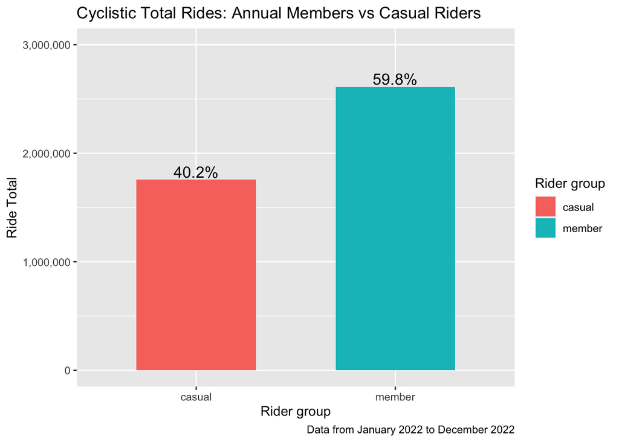

```r
# Plot of ride percentage of casual vs members
cyclistic_2022_cleaned %>%
  ggplot(aes(x = member_casual, fill = member_casual)) +
  geom_bar(width = 0.6) +
  geom_text(
    stat = "count", aes(label = sprintf("%1.1f%%", after_stat(round(count / sum(count) * 100, digits = 1)))),
    position = position_dodge(width = 1.0),
    vjust = -0.2, size = 4.5
  ) +
  scale_y_continuous(labels = comma, limits = c(0, 3000000)) +
  labs(
    title = "Cyclistic Total Rides: Annual Members vs Casual Riders",
    x = "Rider group", y = "Ride Total", fill = "Rider group",
    caption = "Data from January 2022 to December 2022"
  )
```

The calculations and bar chart reveal that over the course of January 2022 to December 2022, there were a total of 4,369,044 rides with 59.8% of the rides completed by members and 40.2% completed by casuals. This shows that there’s a 20% difference in the total rides completed by cyclistic’s annual members versus its casual riders. Furthermore, I conducted analysis to calculate the average ride length, maximum ride length, minimum ride length, median ride length, as well as the most frequent day of the week for each group of riders.

What do the average, maximum, minimum, median ride lengths say about cyclistic’s rider groups?

```r
# Calculated the average ride length, max ride length, median ride length, and minimum ride length for each groups of riders
cyclistic_2022_cleaned %>%
  group_by(member_casual) %>%
  summarise(mean_ride_length = mean(ride_length_mins), median_ride_length = median(ride_length_mins), max_ride_length = max(ride_length_mins), min_ride_length = min(ride_length_mins))
```

```
## # A tibble: 2 × 5
##   member_casual mean_ride_length median_ride_length max_ride_length
##   <chr>         <drtn>           <drtn>             <drtn>
## 1 casual        23.99451 mins    13.85 mins         34354.07 mins
## 2 member        12.45240 mins     8.98 mins          1493.23 mins
## # ℹ 1 more variable: min_ride_length <drtn>
```

```r
# Calculated the average ride time by each day for members vs casual users
aggregate(cyclistic_2022_cleaned$ride_length ~ cyclistic_2022_cleaned$member_casual + cyclistic_2022_cleaned$start_day_of_the_week, FUN = mean)
```

```
##    cyclistic_2022_cleaned$member_casual
## 1                                casual
## 2                                member
## 3                                casual
## 4                                member
## 5                                casual
## 6                                member
## 7                                casual
## 8                                member
## 9                                casual
## 10                               member
## 11                               casual
## 12                               member
## 13                               casual
## 14                               member
```

[output cut: 30 more lines]

```r
# Ordered the days of the week
cyclistic_2022_cleaned$start_day_of_the_week <- factor(cyclistic_2022_cleaned$start_day_of_the_week, c("Monday", "Tuesday", "Wednesday", "Thursday", "Friday", "Saturday", "Sunday"))

# Compare members and casual users
aggregate(cyclistic_2022_cleaned$ride_length ~ cyclistic_2022_cleaned$member_casual, FUN = mean)
```

```
##   cyclistic_2022_cleaned$member_casual cyclistic_2022_cleaned$ride_length
## 1                               casual                     1439.6708 secs
## 2                               member                      747.1441 secs
```

```r
aggregate(cyclistic_2022_cleaned$ride_length ~ cyclistic_2022_cleaned$member_casual, FUN = median)
```

```
##   cyclistic_2022_cleaned$member_casual cyclistic_2022_cleaned$ride_length
## 1                               casual                           831 secs
## 2                               member                           539 secs
```

```r
aggregate(cyclistic_2022_cleaned$ride_length ~ cyclistic_2022_cleaned$member_casual, FUN = max)
```

```
##   cyclistic_2022_cleaned$member_casual cyclistic_2022_cleaned$ride_length
## 1                               casual                       2061244 secs
## 2                               member                         89594 secs
```

```r
aggregate(cyclistic_2022_cleaned$ride_length ~ cyclistic_2022_cleaned$member_casual, FUN = min)
```

```
##   cyclistic_2022_cleaned$member_casual cyclistic_2022_cleaned$ride_length
## 1                               casual                             1 secs
## 2                               member                             1 secs
```

#### Created a bar chart showing the average length ride per day of the week for each rider group

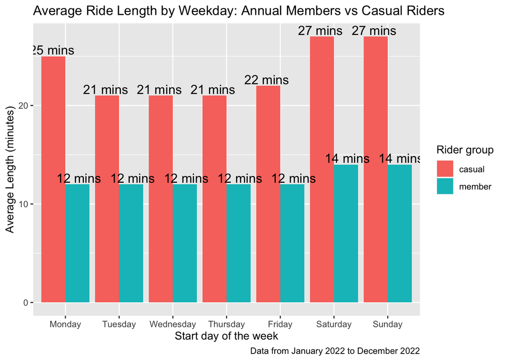

```r
# Plot of average ride duration by weekday for both rider groups
cyclistic_2022_cleaned %>%
  group_by(member_casual, start_day_of_the_week) %>%
  summarise(
    number_of_rides = n(),
    average_length = round(mean(ride_length_mins))
  ) %>%
  arrange(member_casual, start_day_of_the_week) %>%
  ggplot(aes(x = start_day_of_the_week, y = average_length, fill = member_casual)) +
  geom_bar(stat = "identity", position = "dodge") +
  geom_text(
    aes(label = paste(average_length, "mins")),
    position = position_dodge(width = 1.0),
    vjust = -0.2, size = 4.5
  ) +
  labs(
    title = "Average Ride Length by Weekday: Annual Members vs Casual Riders",
    x = "Start day of the week", y = "Average Length (minutes)", fill = "Rider group",
    caption = "Data from January 2022 to December 2022"
  )
```

In addition, what trends do the most popular days of the week show?

#### Calculated the most popular ride days for each group of riders

```r
# Created two filtered datasets including only one group of riders
cyclistic_2022_member <- filter(cyclistic_2022_cleaned, member_casual == "member")
cyclistic_2022_casual <- filter(cyclistic_2022_cleaned, member_casual == "casual")

# Created a function to calculate mode
getmode <- function(v) {
  uniqv <- unique(v)
  uniqv[which.max(tabulate(match(v, uniqv)))]
}

# Calculated mode for start days for both rider groups
getmode(cyclistic_2022_member$start_day_of_the_week)
```

```
## [1] Thursday
## Levels: Monday Tuesday Wednesday Thursday Friday Saturday Sunday
```

```r
getmode(cyclistic_2022_casual$start_day_of_the_week)
```

```
## [1] Saturday
## Levels: Monday Tuesday Wednesday Thursday Friday Saturday Sunday
```

#### Created a bar chart showing the percentage of total rides per day of the week for each rider group

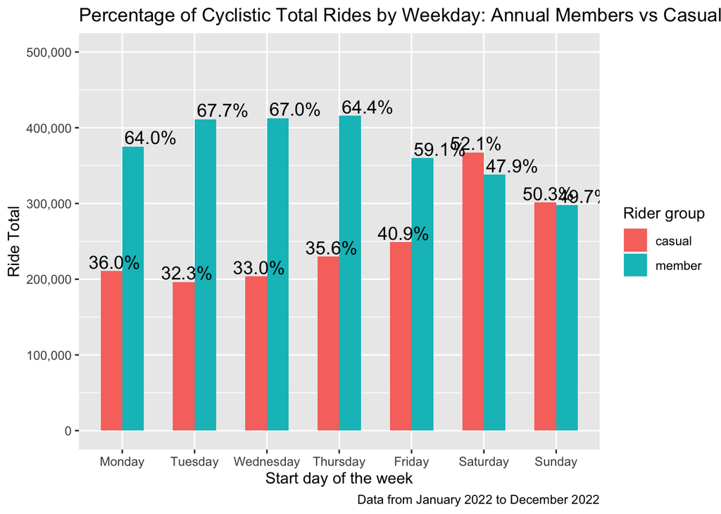

```r
# Plot of ride percentage by weekdays
cyclistic_2022_cleaned %>%
  ggplot(aes(x = start_day_of_the_week, fill = member_casual)) +
  geom_bar(width = 0.6, position = "dodge") +
  geom_text(
    aes(label = scales::percent(signif(after_stat(count) / tapply(after_stat(count), ..x.., sum)[..x..], digits = 3))),
    position = position_dodge(width = 1.0),
    vjust = -0.2, hjust = 0.3, size = 4.5,
    stat = "count"
  ) +
  scale_y_continuous(labels = comma, limits = c(0, 500000)) +
  labs(
    title = "Percentage of Cyclistic Total Rides by Weekday: Annual Members vs Casual Riders",
    x = "Start day of the week", y = "Ride Total", fill = "Rider group",
    caption = "Data from January 2022 to December 2022"
  )
```

The calculations and bar chart reveal that the total rides for casual riders are higher during the weekends and exceed those of annual members while the total rides for annual members are higher during the week and exceed those of casual riders during these respective time frames. Thursday is the most popular day for annual members while Saturday is the most popular day for casual riders. Sunday is the least popular day for annual members while Tuesday is the least popular day for casual riders.

I analyzed the hourly data of the dataset to dig deeper and discover more insight about each rider group.

#### Counted the total number of riders per hour start time of the day

```r
# Count the number of rides per hour of the day
hourly_rides <- cyclistic_2022_cleaned %>%
  group_by(member_casual, hour_time) %>%
  summarise(number_of_rides = n()) %>%
  arrange(hour_time)
hourly_rides
```

```
## # A tibble: 48 × 3
## # Groups:   member_casual [2]
##    member_casual hour_time number_of_rides
##    <chr>         <chr>               <int>
##  1 casual        00                  33310
##  2 member        00                  25221
##  3 casual        01                  21320
##  4 member        01                  15554
##  5 casual        02                  12672
##  6 member        02                   8593
##  7 casual        03                   7199
##  8 member        03                   5243
##  9 casual        04                   4660
## 10 member        04                   6160
## # ℹ 38 more rows
```

#### Created a bar chart to show the hourly start time ride data between both rider groups

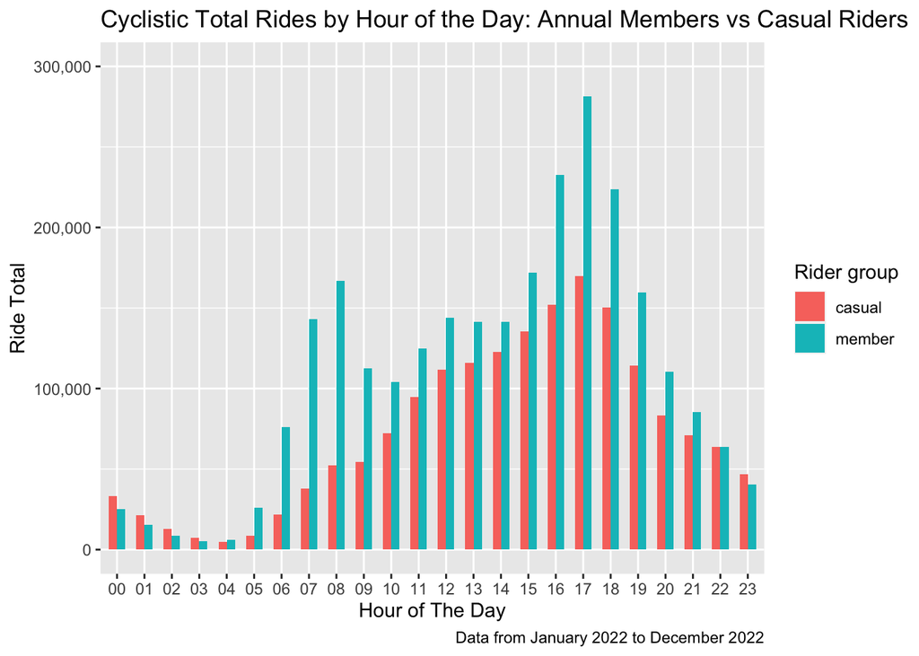

```r
# Plot of total rides by start hour
cyclistic_2022_cleaned %>%
  ggplot(aes(x = hour_time, fill = member_casual)) +
  geom_bar(width = 0.6, position = "dodge") +
  scale_y_continuous(labels = comma, limits = c(0, 300000)) +
  labs(
    title = "Cyclistic Total Rides by Hour of the Day: Annual Members vs Casual Riders",
    x = "Hour of The Day", y = "Ride Total", fill = "Rider group",
    caption = "Data from January 2022 to December 2022"
  )
```

As shown by the chart, the total number of rides for annual members peaked at 8 a.m. and 5 p.m., while, the total number of rides for casual riders peaked at 5 p.m. These findings indicate that based on the trends discovered across the hourly start times and days of the week, annual members are using Cyclistic’s ride share to commute to and from work/school, while casual riders are using Cyclistic’s ride share for leisure purposes.

I decided to explore how the total number of rides change from to month over the course of the year.

#### Counted the total number of rides per month of the year for each rider group

```r
# Counted the number of rides per month
monthly_rides <- cyclistic_2022_cleaned %>%
  group_by(member_casual, month) %>%
  summarise(number_of_rides = n()) %>%
  arrange(month)
monthly_rides
```

```
## # A tibble: 24 × 3
## # Groups:   member_casual [2]
##    member_casual month number_of_rides
##    <chr>         <ord>           <int>
##  1 casual        Jan             12605
##  2 member        Jan             67523
##  3 casual        Feb             15143
##  4 member        Feb             74031
##  5 casual        Mar             67150
##  6 member        Mar            148821
##  7 casual        Apr             91889
##  8 member        Apr            180657
##  9 casual        May            220232
## 10 member        May            282284
## # ℹ 14 more rows
```

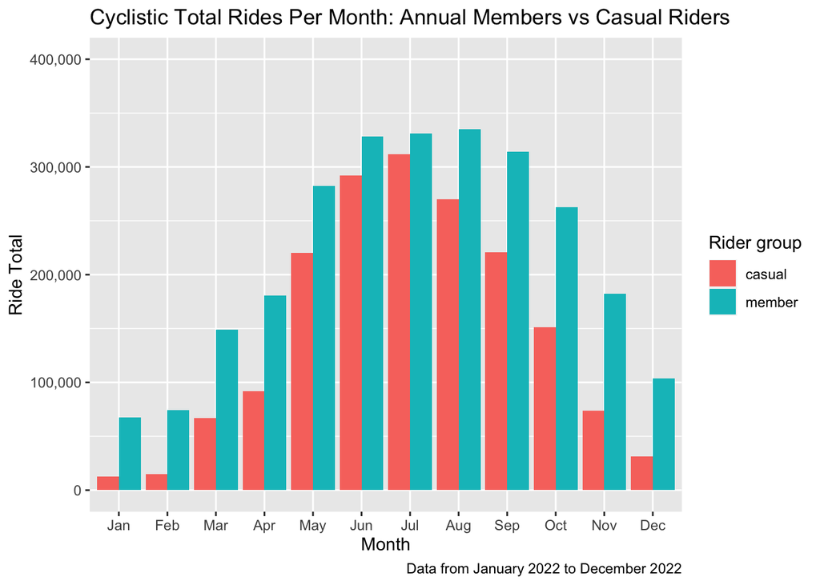

```r
# Plot of total rides by month
monthly_rides %>%
  ggplot(aes(fill = member_casual, y = number_of_rides, x = month)) +
  geom_bar(position = "dodge", stat = "identity") +
  labs(
    title = "Cyclistic Total Rides Per Month: Annual Members vs Casual Riders",
    x = "Month", y = "Ride Total", fill = "Rider group",
    caption = "Data from January 2022 to December 2022"
  ) +
  scale_y_continuous(labels = comma, limits = c(0, 400000))
```

The chart shows a bell curve with total number of rides for both casual riders and members peaking during summer months, this could be attributed to the annual climate in Chicago.

In addition, I decided investigate the choice differences in the rideable type of each group of riders by calculating the total number of rides per rideable type for each group of riders and visualizing this data in a bar chart.

#### Counted the totalnumber of rides per rideable type for each group of riders

```r
# Count number of rides per rideable type
rideable_type_rides <- cyclistic_2022_cleaned %>%
  group_by(member_casual, rideable_type) %>%
  summarise(number_of_rides = n()) %>%
  arrange(rideable_type)
rideable_type_rides
```

```
## # A tibble: 5 × 3
## # Groups:   member_casual [2]
##   member_casual rideable_type number_of_rides
##   <chr>         <chr>                   <int>
## 1 casual        classic_bike           888727
## 2 member        classic_bike          1708567
## 3 casual        docked_bike            174852
## 4 casual        electric_bike          694466
## 5 member        electric_bike          902432
```

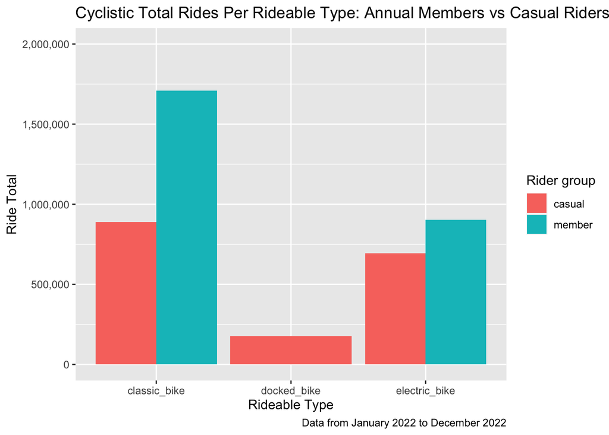

```r
# Plot of total rides by rideable type
rideable_type_rides %>%
  ggplot(aes(fill=member_casual, y=number_of_rides, x=rideable_type)) +
  geom_bar(position="dodge", stat="identity") +
  labs(title = "Cyclistic Total Rides Per Rideable Type: Annual Members vs Casual Riders",
       x = "Rideable Type", y = "Ride Total", fill = "Rider group",
       caption = "Data from January 2022 to December 2022"
  ) +
  scale_y_continuous(labels = comma, limits = c(0, 2000000))
```

The chart reveals that: classic bikes are most the most popular rideable used by both annual members, electric bikes are the second most popular rideable type used by both groups, and docked bikes are used exclusively by casual riders.

Lastly, I analyzed the most used start stations by each group of riders to discover what insight they reveal.

#### Counted the most popular start stations for each group of riders

```r
# Popular station for casual customers
start_station_casual <- cyclistic_2022_casual %>%
  group_by(start_station_name) %>%
  summarise(number_of_rides = n()) %>%
  arrange(desc(number_of_rides))

head(start_station_casual, n=10)
```

```
## # A tibble: 10 × 2
##    start_station_name                 number_of_rides
##    <chr>                                        <int>
##  1 Streeter Dr & Grand Ave                      55054
##  2 DuSable Lake Shore Dr & Monroe St            30261
##  3 Millennium Park                              23948
##  4 Michigan Ave & Oak St                        23760
##  5 DuSable Lake Shore Dr & North Blvd           22156
##  6 Shedd Aquarium                               19421
##  7 Theater on the Lake                          17332
##  8 Wells St & Concord Ln                        14833
##  9 Dusable Harbor                               13270
## 10 Clark St & Armitage Ave                      12777
```

```r
# Popular station for casual customers
start_station_member <- cyclistic_2022_member %>%
  group_by(start_station_name) %>%
  summarise(number_of_rides = n()) %>%
  arrange(desc(number_of_rides))

head(start_station_member, n=10)
```

```
## # A tibble: 10 × 2
##    start_station_name           number_of_rides
##    <chr>                                  <int>
##  1 Kingsbury St & Kinzie St               23523
##  2 Clark St & Elm St                      20578
##  3 Wells St & Concord Ln                  19674
##  4 Clinton St & Washington Blvd           18828
##  5 Loomis St & Lexington St               18252
##  6 Clinton St & Madison St                18007
##  7 University Ave & 57th St               17578
##  8 Ellis Ave & 60th St                    17503
##  9 Wells St & Elm St                      17495
## 10 Streeter Dr & Grand Ave                16205
```

```r
# Number of rides per station for both customer type
start_station_all <- cyclistic_2022_cleaned %>%
  group_by(start_station_name, member_casual) %>%
  summarise(number_of_rides = n()) %>%
  arrange(desc(number_of_rides))
```

#### Consolidated the start stations into a data frame with unique geographical coordinates for each stations

```r
# Created a data frame containing every stations id, name, and unique coordinates.
unique_station_coord <- cyclistic_2022_cleaned %>%
  select(start_station_name, start_lat, start_lng) %>%
  distinct(start_station_name, .keep_all = TRUE)

# Merge data
unique_station_coord <- start_station_all %>%
  left_join(unique_station_coord, by = "start_station_name")

head(unique_station_coord)
```

```
## # A tibble: 6 × 5
## # Groups:   start_station_name [6]
##   start_station_name           member_casual number_of_rides start_lat start_lng
##   <chr>                        <chr>                   <int>     <dbl>     <dbl>
## 1 Streeter Dr & Grand Ave      casual                  55054      41.9     -87.6
## 2 DuSable Lake Shore Dr & Mon… casual                  30261      41.9     -87.6
## 3 Millennium Park              casual                  23948      41.9     -87.6
## 4 Michigan Ave & Oak St        casual                  23760      41.9     -87.6
## 5 Kingsbury St & Kinzie St     member                  23523      41.9     -87.6
## 6 DuSable Lake Shore Dr & Nor… casual                  22156      41.9     -87.6
```

#### Created a leaflet map object to visualize the total number number of rides per start station for each group of riders

## Map Showing Total Rides Per Start Station

```r
# Map of total number of rides per start station
map <- leaflet() %>%
  addTiles()

map <- map %>%
  addCircleMarkers(
    data = subset(unique_station_coord[1:100,], member_casual == "casual"),
    lat = ~start_lat,
    lng = ~start_lng,
    label = ~paste(start_station_name, "Rides:", number_of_rides),
    color = "red",
    radius = 5,
    group = "Casual"
  ) %>%
  addCircleMarkers(
    data = subset(unique_station_coord[1:100,], member_casual == "member"),
    lat = ~start_lat,
    lng = ~start_lng,
    label = ~paste(start_station_name, "Rides:", number_of_rides),
    color = "blue",
    radius = 5,
    group = "Member"
  )

map <- map %>%
  addLayersControl(
    overlayGroups = c("Casual", "Member"),
    options = layersControlOptions(collapsed = FALSE)
  )
map
```

[interactive chart not shown]

The map reveals that although the distribution of stations used by both groups show some overlap, the stations used mostly by annual members tend to be located towards the inner city while the stations used mostly by casual riders lie in closer proximity to the outskirts of the city. This supports our findings of annual members predominantly using cyclistic’s ride share for work/school weekly commutes and casual riders using cyclistic’s ride share for leisure commutes.

I exported my cleaned dataset as a csv file and uploaded it to my tableau workspace for further alternative visualizations. I created the following interactive dashboard showing the total rides at their respective times per day of the week for each group of riders, as well as a column chart ranking the most used stations by each group of riders.

```r
write.csv(cyclistic_2022_cleaned, "cyclistic_2022_cleaned.csv")
```

[figure not shown]

## Recommendations:

In conclusion, based on the findings from this analysis, members are using Cyclistic to commute to and from work/school, while casuals are using Cyclistic for leisure purposes.

I would suggest: 1. Designing marketing campaigns aimed at providing benefits and incentives which encourage casual riders to use Cyclistic to commute to and from work or school (e.g. Member Exclusive discounts)

2. Partnering up with work organizations and/or schools to offer member exclusive discounts or perks.
3. Target the most used stations by casual riders when advertising - Streeter Dr & Grand Ave, DuSable Lake Shore Dr & Monroe Dt, and Millennium Park.
4. Run ad campaigns during times when most casual members aren’t using Cyclistic Ride share – 8 a.m. to 10 a.m.
5. Create a reward system where members can accrue points for completing more rides and redeem such points for rewards or prizes.